# small_database

## Μέρος Α

#### Στοιχεία Ομάδας

Παπακωνσταντίνου Πολύβιος 03114892

Πατρής Νικόλαος 03114861

```python
import warnings
warnings.filterwarnings('ignore')
```

## Μέρος Β

#### Εισαγωγή του dataset

Θα εισάγουμε και θα διαβάζουμε το csv αρχείο `sonar.all-data` με την χρήση της read_csv και option "header=None" γιατί η πρώτη γραμμή περιέχει δεδομένα.

```python
import pandas as pd
df = pd.read_csv("sonar.all-data", header=None)
```

#### Παρουσίαση του dataset.

Στόχος του dataset είναι να εκπαιδεύσει ένα νευρωνικό δίκτυο να διακρίνει ηχοεντοπιστικά σήματα (sonars) τα οποία αντανακλώνται είτε απο μεταλικούς κυλίνδρους είτε από κυλινδρικούς βράχους/πέτρες.

Κάθε δείγμα αποτελείται απο 60 αριθμούς (δείγματα) στο διάστημα $[0.0,1.0]$, ένω κάθε αριθμός αναπαριστά την ενέργεια που εμφανίζεται σε διαφορετικά φάσματα συχνοτήτων μέσα σε ένα χρονικό διάστημα.

#### Αριθμός δειγμάτων και χαρακτηριστικών, είδος χαρακτηριστικών. Υπάρχουν μη διατεταγμένα χαρακτηριστικά και ποια είναι αυτά;

```python
print("# Samples: {}, # Features: {}".format(df.shape[0], df.shape[1]-1))
print(df.head())
```

```
# Samples: 208, # Features: 60
       0       1       2       3       4       5       6       7       8   \
0  0.0200  0.0371  0.0428  0.0207  0.0954  0.0986  0.1539  0.1601  0.3109
1  0.0453  0.0523  0.0843  0.0689  0.1183  0.2583  0.2156  0.3481  0.3337
2  0.0262  0.0582  0.1099  0.1083  0.0974  0.2280  0.2431  0.3771  0.5598
3  0.0100  0.0171  0.0623  0.0205  0.0205  0.0368  0.1098  0.1276  0.0598
4  0.0762  0.0666  0.0481  0.0394  0.0590  0.0649  0.1209  0.2467  0.3564

       9  ...      51      52      53      54      55      56      57      58  \
0  0.2111 ...  0.0027  0.0065  0.0159  0.0072  0.0167  0.0180  0.0084  0.0090
1  0.2872 ...  0.0084  0.0089  0.0048  0.0094  0.0191  0.0140  0.0049  0.0052
2  0.6194 ...  0.0232  0.0166  0.0095  0.0180  0.0244  0.0316  0.0164  0.0095
3  0.1264 ...  0.0121  0.0036  0.0150  0.0085  0.0073  0.0050  0.0044  0.0040
4  0.4459 ...  0.0031  0.0054  0.0105  0.0110  0.0015  0.0072  0.0048  0.0107

       59  60
0  0.0032   R
1  0.0044   R
2  0.0078   R
3  0.0117   R
4  0.0094   R

[5 rows x 61 columns]
```

Όπως προείπαμε διαθέτουμε 208 δείγματα (111 μέταλο, 97 πέτρα) και 60 χαρακτηριστικά.

#### Υπάρχουν επικεφαλίδες; Αρίθμηση γραμμών;

Τα δεδομένα είναι σε `row` μορφή μέσα στο αρχείο, χωρίς επικεφαλίδες και αριθμήσεις γραμμών/δειγμάτων.

#### Ποιες είναι οι ετικέτες των κλάσεων και σε ποια κολόνα βρίσκονται;

H 61η στήλη είναι εκείνη που περιγράφει την κλάση κάθε δείγματος: **M** (metal) ή **R** (rock).

```python
import numpy as np

labels = df.iloc[:,-1].unique()
print("Unique Labels of samples: {0}".format(labels))
```

```
Unique Labels of samples: ['R' 'M']
```

#### Χρειάστηκε να κάνετε μετατροπές στα αρχεία text και ποιες?

Έχουμε ήδη αναφερθεί στην μορφή του αρχείου δεδομένων, και στον τρόπο με τον οποία αναγράφονται τα δείγματα. Ωστόσο το μόνο που μένει να τροποποιηθεί είναι η μορφή των labels. Όπως γνωρίζουμε, ένα νευρωνικό δίκτυο δεν ειναι σε θέση να παράγει στην έξοδο του κάποια συμβολοσειρά, αλλά αριθμούς. Για να καταφέρουμε να εκπαιδεύσουμε τον νευρωνικό θα χρειαστεί αρχικά να μετατρέψουμε τα string 'R' και 'M' σε 0 και 1 αντίστοιχα.

Ορίζοντας ένα mapping και εφαρμόζοντας τη μέθοδο replace με το συγκεκριμένο mapping, η μετατροπή γίνεται αυτόματα σε όλα τα δείγματα.

```python
features_df = df.iloc[:,:-1]
labels_df = df.iloc[:,-1]

mapping = {'R': 0, 'M': 1}
labels_df = labels_df.replace(mapping)
```

Μπορούμε τώρα να μετατρέψουμε τα dataframes σε numpy, ώστε να είναι συμβατά με το `scikit-learn`.

```python
features = features_df.values
labels = labels_df.values
```

#### Υπάρχουν απουσιάζουσες τιμές;

Ένας απλός τρόπος να ελέγξουμε αν υπάρχουν απουσιάζουσες τιμές είναι ο παρακάτω:

```python
missing = df.isnull().values.any()
print(missing)
```

```
False
```

Εφόσον μας επιστρέφει false, δεν υπάρχουν απουσιάζουσες τιμές.

#### Ποιος είναι ο αριθμός των κλάσεων και τα ποσοστά δειγμάτων τους επί του συνόλου;

```python
frequencies = np.bincount(labels)
total_samples = frequencies.sum()
percentage = (frequencies / total_samples) * 100

print("""Class frequencies: {0}
Total samples: {1}
Class percentage: {2}""".format(frequencies, total_samples, percentage))
```

```
Class frequencies: [ 97 111]
Total samples: 208
Class percentage: [46.63461538 53.36538462]
```

Παρατηρούμε πως και οι 2 κλάσεις είναι αρκετά κοντά στο 50%, συνεπώς το dataset μας είναι ισορροπημένο.

#### Διαχωρισμός σε train και test sets.

Ο διαχωρισμός του dataset σε train, test θα γίνει με την βοήθεια της έτοιμης ρουτίνας του sklearn. Όσο για την παράμετρο `random_state` μιας και η συμβολή της στον διαχωρισμό είναι ελάχιστή, την αρχικοποιήσαμε στην τιμή 23.

```python
from sklearn.model_selection import train_test_split

X_train, X_test, y_train, y_test = train_test_split(features, labels, test_size=0.20, random_state=23)

print("Split: Train {0}, Test {1}".format(np.bincount(y_train), np.bincount(y_test)))
```

```
Split: Train [73 93], Test [24 18]
```

Παρατηρούμε ωστόσο ότι η συμβολή της `random_state` στον διαχωρισμό αν και μικρή μπορεί να δημιουργήσει *ανισορροπίες* στα δεδομένα που θα παρέχουμε για εκπαίδευση. Ιδιώς στην περίπτωση μας εκπαιδεύουμε την ταξινομητή μας σχεδόν $30\%$ περισσότερο με `M samples`.

Επομένως, επιλέξαμε να ενεργοποιήσουμε και την ικάνοτητα *statify* ώστε να μας παράξει ένα πιο ισορροπημένο διαχωρισμό μεταξύ των δύο κλάσεων.

```python
X_train, X_test, y_train, y_test = train_test_split(features, labels, test_size=0.2, stratify=labels)

print("Split (Stratified): Train {0}, Test {1}".format(np.bincount(y_train), np.bincount(y_test)))
```

```
Split (Stratified): Train [77 89], Test [20 22]
```

## Μέρος Γ

Στο τρίτο μέρος καλούμαστε να εκπαιδεύσουμε τους classifiers με default τιμές που επιλέγουμε εμείς. Ο μόνος παραμετρικός ταξινομητής που έχουμε να εξετάσουμε είναι ο `KNeighborsClassifier` οπότε η τιμή που θα επιλέξουμε για τον αριθμό των γειτόνων, μπορεί να μην οδηγήσει στα βέλτιστα αποτελέσματα.

Αρχικά ορίζουμε όλους του $Dummy\ Classifiers$ και τους εκπαιδεύουμε με το $train\_set$.

```python
from sklearn.dummy import DummyClassifier
from sklearn.metrics import confusion_matrix
from sklearn.metrics import accuracy_score

# Initialize some dummies classifiers

dc_uniform = DummyClassifier(strategy="uniform")
dc_constant_0 = DummyClassifier(strategy="constant", constant=0)
dc_constant_1 = DummyClassifier(strategy="constant", constant=1)
dc_most_frequent = DummyClassifier(strategy="most_frequent")
dc_stratified = DummyClassifier(strategy="stratified")
```

```python
# Train each dummy classifier.

dc_uniform.fit(X_train, y_train)
dc_constant_0.fit(X_train, y_train)
dc_constant_1.fit(X_train, y_train)
dc_most_frequent.fit(X_train, y_train)
dc_stratified.fit(X_train, y_train)
```

```
DummyClassifier(constant=None, random_state=None, strategy='stratified')
```

```python
# Predict values based on test set

pred_uni = dc_uniform.predict(X_test)
pred_const_0 = dc_constant_0.predict(X_test)
pred_const_1 = dc_constant_1.predict(X_test)
pred_freq = dc_most_frequent.predict(X_test)
pred_strat = dc_stratified.predict(X_test)
```

```python
from sklearn.neighbors import KNeighborsClassifier
# kNN Classifier, default k=5

knn = KNeighborsClassifier(n_neighbors=5)
knn.fit(X_train, y_train)
pred_knn = knn.predict(X_test)
```

#### Confusion matrix - Bar Plots F1 (micro/macro) Score

Όλες οι προβλέψεις των ταξινομονητών υπολογίστικαν και αποθηκεύτηκαν σε ξεχωριστές μεταβλητές ώστε να αποφύγουμε τυχόν overwrites. Το επόμενο βήμα είναι να υπολογίσουμε τις κατάλληλες μετρικές και τους πίνακες σύγχυσης που θα μας βοηθήσουν στην ανάλυση των μοντέλων μας. Αποφασίσαμε να γράψουμε ορισμένες ρουτίνες για να αυτοματοποιήσουμε την διαδικασία, και να βοήθησουν στην καλύτερη αναπαράσταση των δεδομένων.

`cnf_score_report`: Μια απλή συνάρτηση που την καλούμε με $y\_test,\ y\_pred$, και επιστρέφει $recall,\ precision, f1\ scores,\ confusion\ matrices$.

```python
from sklearn.metrics import confusion_matrix
from sklearn.metrics import precision_recall_fscore_support

def cnf_score_report(y_test, y_pred):
    cnf_matrix = confusion_matrix(y_test, y_pred)

    f1_micro = precision_recall_fscore_support(y_test, y_pred, average='micro')[2]
    recall_micro = precision_recall_fscore_support(y_test, y_pred, average='micro')[1]
    precision_micro = precision_recall_fscore_support(y_test, y_pred, average='micro')[0]

    f1_macro = precision_recall_fscore_support(y_test, y_pred, average='macro')[2]
    recall_macro = precision_recall_fscore_support(y_test, y_pred, average='macro')[1]
    precision_macro = precision_recall_fscore_support(y_test, y_pred, average='macro')[0]

    return (cnf_matrix, round(precision_micro,4), round(recall_micro,4), round(f1_micro,4), round(precision_macro,4), round(recall_macro,4), round(f1_macro,4))
```

Η επόμενη συνάρτηση αφορά την παρουσίαση των πινάκων σύγχυσης. Θεωρήσαμε ότι η εμφάνιση τους σαν απλούς `numpy arrays` δεν θα βοηθούσε ιδιαίτερα στην μελέτη, οπότε προχωρήσαμε στην αναζήτηση μιας πιο εξειδικευμένης συνάρτησης, που με συνδυασμό με την βιβλιοθήκη `matplotlib`, θα τους εμφάνιζε με τρόπο παρόμοιο με αυτόν που είδαμε στο εργαστήριο. Ο παρακάτω κώδικας, είναι μία **ελαφρώς** τροποποιημένη μορφή του αρχικού που βρήκαμε στην σελίδα του sklearn.

```python
"""
Confusion Matrix Plotter from sklearn
https://scikit-learn.org/stable/auto_examples/model_selection/plot_confusion_matrix.html
"""

import itertools
import matplotlib.pyplot as plt

def plot_confusion_matrix(cm, classes,
                          normalize=False,
                          title='Confusion matrix',
                          cmap=plt.cm.Blues):
    """
    This function prints and plots the confusion matrix.
    Normalization can be applied by setting `normalize=True`.
    """
    if normalize:
        cm = cm.astype('float') / cm.sum(axis=1)[:, np.newaxis]
#         print("Normalized confusion matrix")
    else:
        pass
#         print('Confusion matrix, without normalization')

#     print(cm)

    plt.imshow(cm, interpolation='nearest', cmap=cmap)
    plt.title(title)
    plt.colorbar()
    tick_marks = np.arange(len(classes))
    plt.xticks(tick_marks, classes, rotation=45)
    plt.yticks(tick_marks, classes)

    fmt = '.2f' if normalize else 'd'
    thresh = cm.max() / 2.
    for i, j in itertools.product(range(cm.shape[0]), range(cm.shape[1])):
        plt.text(j, i, format(cm[i, j], fmt),
                 horizontalalignment="center",
                 color="black" if cm[i, j] > thresh else "black")

    plt.ylabel('True label')
    plt.xlabel('Predicted label')
    plt.tight_layout()
```

Η επόμενη συνάρτηση κάνει χρήση της κλάσης που ανήκει κάθε ταξινομητής, και διαμορφώνει το κατάλληλο string, που θα χρησιμοποιηθεί ως όνομα του `x-axis` για κάθε ένα ταξινομητή τόσο στους πίνακες σύγχυσης όσο και στο barplot.

```python
def transfrom_title(class_type):
    split_title = class_type.replace(")", "").split("(")
    clf_name = split_title[0]

    if (clf_name == "DummyClassifier"):
        return clf_name + split_title[1].split(",")[2]
    elif (clf_name == "KNeighborsClassifier"):
        return clf_name + split_title[1].split(",")[5]
```

Η `plot-report` χρησιμοποιεί τις παραπάνω τρεις συναρτήσεις που σχολιάσαμε και εμφανίζει σε διαφορετικό figure τους confusion matrices, για κάθε ένα ταξινομητή. Ως όρισμα μπορεί να δεχτεί και έναν μεμονωμένο ταξινομητή αλλά και μια λίστα εξ αυτών διαμορφώνοντας κατάλληλα το input για να δουλέψει η for loop. Επίσης δέχεται και μια λίστα ονομάτων, ώστε να αντιστοιχίσει κάθε binary κλάση, με το ονόμα που την περιγράφει.

```python
def plot_report(clfs, X_test, y_test, classes):
    if not isinstance(clfs, list):
        clfs = [clfs]

    for i, clf in enumerate(clfs):
        plt.figure(i)
        y_pred = clf.predict(X_test)
        cnf_matrix, precision_micro, recall_micro, f1_micro, precision_macro, recall_macro, f1_macro = cnf_score_report(y_test, y_pred)

        title = transfrom_title(str(clf))
        title = "{0} \n [Micro] Precision: {1} Recall: {2}, F1: {3} \n [Macro] Precision: {4} Recall: {5}, F1: {6}".format(title, precision_micro, recall_micro, f1_micro, precision_macro, recall_macro, f1_macro)
        plot_confusion_matrix(cnf_matrix, title=title, classes=classes)

    plt.show()
```

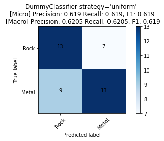

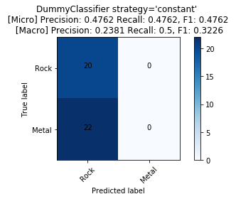

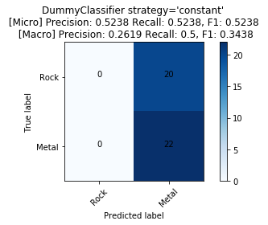

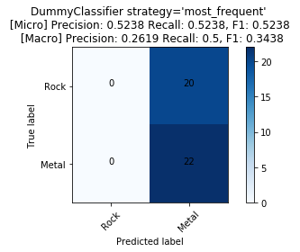

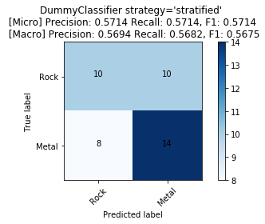

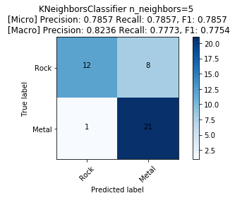

```python
clfs = [dc_uniform, dc_constant_0, dc_constant_1, dc_most_frequent, dc_stratified, knn]
plot_report(clfs, X_test, y_test, ["Rock", "Metal"])
```

Η `barplot_score` εμφανίζει τα δύο ζητούμενα bar plots για τις δύο μετρικές $f1\_micro,\ f1\_macro$. Επειδή τα ονόματα των ταξινομητών είναι αρκετά μεγάλα για τον x-άξονα, στην περίπτωση των **Dummies** εμφανίζουμε μόνο την στρατηγική που ακολουθεί, ενώ στον **KNeighbors** των αριθμό των γειτόνων.

```python
def barplot_score(clfs, X_test, y_test):
    if not isinstance(clfs, list):
        clfs = [clfs]

    micro_l = []
    macro_l = []
    clf_name = []

    for clf in clfs:
        _, _, _, f1_micro, _, _, f1_macro = cnf_score_report(y_test, clf.predict(X_test))

        micro_l.append(f1_micro)
        macro_l.append(f1_macro)
        clf_name.append(transfrom_title(str(clf)).split()[1])

    y_pos = np.arange(len(clf_name))

    plt.figure(1)
    plt.bar(y_pos, micro_l, align='center', alpha=0.9)
    plt.xticks(y_pos, clf_name, rotation=45)
    plt.ylabel('Score')
    plt.title('f1 micro')
    plt.tight_layout()

    plt.figure(2)
    plt.bar(y_pos, macro_l, align='center', alpha=0.9)
    plt.xticks(y_pos, clf_name, rotation=45)
    plt.ylabel('Score')
    plt.title('f1 macro')
    plt.tight_layout()
```

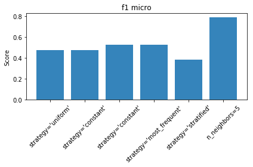

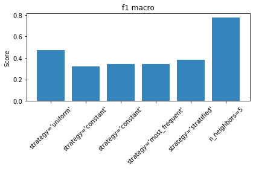

```python
barplot_score(clfs, X_test, y_test)
```

Καταρχάς παρατηρούμε πως για average = 'micro', οι τιμές των `precision` και `recall` (και προφανώς του f1) είναι ίδιες για κάθε classifier ξεχωριστά.

Αυτό συμβαίνει επειδή στο micro averaging, τα `FalsePositive` είναι ίσα με τα `FalseNegative` στον τύπο αφού υπολογίζονται **globally**.

Για παράδειγμα αν ένα δείγμα κλάσης Α υπολογίστηκε ως Β, για την κλάση Α θα είναι `FalseNegative`, ενώ για την Β `FalsePositive`. Οπότε το αποτέλεσμα των recall και presicion προφανώς **θα ισούται**.

$$ Precision_{micro} = \frac{TP_1 + TP2}{TP_1 + FP_1 + TP_2 + FP_2} \\ Recall_{micro} = \frac{TP_1 + TP2}{TP_1 + FN_1 + TP_2 + FN_2} $$

Αντίθετα, στο macro averaging υπολογίζουμε τα recall και precision για κάθε κλάση ξεχωριστά και έπειτα τα συνυπολογίζουμε.

$$ Precision_{macro} = \frac{Precision_1 + Precision_2}{2} \\ Recall_{macro} = \frac{Recall_1 + Recall_2}{2} $$

Επίσης με τον ίδιο τρόπο εξηγείται γιατί στους `constant 0`, `constant 1` και `most frequent` (όπου για μια κλάση έχουμε πάρα πολλά FalseNegative/FalsePositive, ενώ για την άλλη ελάχιστα) το macro averaging υπολογίζει σημαντικά χαμηλότερες τιμές (εκτός από το recall το οποίο προφανώς υπολογίζεται στο 0.5).

$$ Precision = \frac{TP}{TP+FP} \\ Recall = \frac{TP}{TP+FN} $$

Η `stratified` από την άλλη κάνει τα predictions ανάλογα με την ισορροπία του dataset, που στην περίπτωση μας είναι σε καλό επίπεδο. Και πάλι όμως παρατηρούμε πως τα αποτελέσματα και για αυτή τη στρατηγική είναι αρκετά χαμηλά.

Τέλος, οφείλουμε να αναφέρουμε πως οι `dummy classifiers` είναι αρκετά απλοί στην υλοποίηση και στη φιλοσοφία τους, εξού και τα χαμηλά αποτελέσματα σε σχέση με τον `knn`. Για παράδειγμα όταν επιλέγουμε στρατηγική `uniform`, οι προβλέψεις μας είναι τυχαίες και γι' αυτό αν ξανατρέξουμε τον classifier θα μας βγάλει εντελώς διαφορετικά αποτελέσματα, γεγονός που δείχνει πως είναι αρκετά αναξιόπιστη.

## Μέρος Δ

Το τελευταίο και σημαντικότερο μέρος της εργασίας αφορά βεβαίως την βελτιστοποίηση των υπερπαραμέτρων. Μια διαδικασία ιδιαιτέρως απαιτητική σε χρόνο καθώς απαιτεί μεγάλο πλήθος δοκιμών για κάθε υπερπαράμετρο. Δυστυχώς ρουτίνες όπως η `GridSearchCV` δεν επιτρέπεται να χρησιμοποιηθούν για να αυτοματοποιήσουν την διαδικασία. Μετά λοιπόν απο δοκιμές αποφασίσαμε να γράψουμε την δική μας κλάση που θα βοήθησει στην εύρεση των κατάλληλων τιμών. Βεβαίως δεν μπορεί να ανταγωνιστεί συναρτήσης που παρέχει το sklearn, παρόλα αυτά οδηγεί σε σωστά αποτέλεσματα.

Προσπαθήσαμε λοιπόν να συνχωνεύσουμε την κλάση `Pipeline` και `GridSearchCV` που παρέχει το `sklearn` σε μια ενιαία κλάση, με αντίστοιχες δυνατότητες. Πέραν λοιπόν του estimator που ορίζεται πρώτος, το δεύτερο όρισμα (grid) δέχεται ένα λεξικό (dict) στο οποίο αναφέρονται οι τιμές των παραμέτρων που θέλεις να δοκιμάσεις και συγκεκριμένα οι εξής.

- vthreshold
- n_components
- k_neighbors

Επιτρέπεται επίσης η χρήση ενός εξισορροπιστεί δεδομένων, και συγκεκριμένα του `RandomOverSampler`, αφού μετά απο δοκιμές κρίθηκε ακατάλληλη η χρήση του `UnderSampler` καθώς αφαιρεί χρήσιμη πληροφορία, από ένα ήδη μικρό dataset. Επίσης λόγω της μορφής των features (τιμές μεταξύ [0,1]), επιλέξαμε να χρησιμοποιήσουμε μόνο των `Standard Scaler`, αφού και πάλι έπειτα απο δοκιμές οδήγησε σε καλύτερα αποτέλεσμα για τους εκτιμητές μας. Τέλος για να μπορούμε να παρέχουμε στο `Cross Validation` τις σωστές τιμές για την αριθμό των folds και το score που θας μας επιστρέψει, χρησιμοποιήσαμε δύο επιπλεόν παραμέτρους που θα παρέχουμε ως ορίσματα στην ρουτινά `cross_val_score`.

```python
from sklearn.feature_selection import VarianceThreshold
from sklearn.preprocessing import StandardScaler
from imblearn.over_sampling import RandomOverSampler
from sklearn.decomposition import PCA
from sklearn.model_selection import cross_val_score
from itertools import product

class GridSearch():
    vthreshold = [0]
    n_components = [0]
    k_neighbors = [1]
    isknn = False

    def __init__(self, estimator, grid, cv='10', scoring='f1_macro', std_scale=True, over_sampling=True):
        self.estimator = estimator
        self.cv = cv
        self.scoring = scoring
        self.std_scale = std_scale
        self.over_sampling = over_sampling

        self.selector = VarianceThreshold()
        self.pca = PCA()
        self.scaler = StandardScaler()

        self.__set_grid__(grid)

        self.X_train = None
        self.y_train = None

        if (str(estimator).split("(")[0] == "KNeighborsClassifier"):
            self.isknn = True

        self.best_estimator_ = None
        self.best_params_ = None

    def __set_grid__(self, grid):
        if not isinstance(grid, dict):
            raise("grid must be dict")

        for key, value in grid.items():
            if (key == "vthreshold"):
                self.vthreshold = sorted(value)
            elif (key == "n_components"):
                self.n_components = sorted(value)
            elif (key == "k_neighbors"):
                self.k_neighbors = sorted(value)

    def fit(self, X_train, y_train):
        self.X_train = X_train
        self.y_train = y_train

        self.max_X_var = max(np.var(X_train, axis=0))

        cv_scores = {}

#         self.vthreshold = [i for i in self.vthreshold if i <= max_X_var]

#         self.n_components = [i for i in self.n_components if i <= X_train.shape[-1]]

        for vh, pca_n in product(self.vthreshold, self.n_components):
            self.selector.set_params(threshold=vh)

            X_train_mod = self.selector.fit_transform(self.X_train)
            X_test_mod = self.selector.transform(X_test)

            if (self.std_scale):
                X_train_mod = self.scaler.fit_transform(X_train_mod)
                X_test_mod = self.scaler.transform(X_test_mod)

            if (self.over_sampling):
                ros = RandomOverSampler(random_state=None, ratio=None, return_indices=False, sampling_strategy='auto')
                X_train_mod, y_train_mod = ros.fit_sample(X_train_mod, self.y_train)
            else:
                y_train_mod = self.y_train

            self.pca.set_params(n_components=pca_n)
            X_train_mod = self.pca.fit_transform(X_train_mod)

#             print("Variance Threshold: {0} PCA Components: {1}".format(vh, pca_n), end="")

            if self.isknn:
                for k in self.k_neighbors:

                    if (k >= X_train_mod.shape[0]):
                        break

                    self.estimator.set_params(n_neighbors=k)

                    score = cross_val_score(self.estimator, X_train_mod, y_train_mod, cv=self.cv, scoring=self.scoring).mean()
                    cv_scores["VH:{0},PCA_N:{1},STD_SCL:{2},OVERSAMPL:{3},KNN:{4}".format(vh, pca_n, self.std_scale, self.over_sampling, k)] = score

#                     print("\nKNN: {0} Score: {1}".format(k, score))
            else:
                score = cross_val_score(self.estimator, X_train_mod, y_train_mod, cv=self.cv, scoring=self.scoring).mean()

                cv_scores["VH:{0},PCA_N:{1},STD_SCL:{2},OVERSAMPL:{3},KNN:NaN".format(vh, pca_n, self.std_scale, self.over_sampling)] = score

#                 print("\nScore: {0}".format(score))

        self.cv_scores = cv_scores
        self.__get_best_estimator_()

    def __fix_type(self, str_value):
        if (str_value == "True"):
            return True
        elif (str_value == "False"):
            return False
        elif (str_value == "NaN"):
            return -1
        else:
            return float(str_value)

    def __key2params(self, key_string):
        params_dict = {}
        splited_key = key_string.split(",")

        for attr in splited_key:
            key, value = attr.split(":")

            if (key == "VH"):
                params_dict["VarianceThreshold"] = self.__fix_type(value)
            elif (key == "PCA_N"):
                params_dict["PCA_components"] = self.__fix_type(value)
            elif (key == "STD_SCL"):
                params_dict["Standard_Scaler"] = self.__fix_type(value)
            elif (key == "OVERSAMPL"):
                params_dict["Over_Sampling"] = self.__fix_type(value)
            elif (key == "KNN"):
                params_dict["KNN_neighbors"] = self.__fix_type(value)

        return params_dict

    def __get_best_params_(self):
        max_score = -1
        max_score_params = ""

        for key,value in self.cv_scores.items():
            if value > max_score:
                max_score = value
                max_score_params = key

        self.max_score = max_score
        self.max_score_params = max_score_params

    def __get_best_estimator_(self):
        self.__get_best_params_()

        X_train_mod = self.X_train
        y_train_mod = self.y_train

        self.best_params_ = self.__key2params(self.max_score_params)

        # Variance Selector
        self.selector.set_params(threshold=self.best_params_["VarianceThreshold"])
        X_train_mod = self.selector.fit_transform(self.X_train)

        # Standard Scaler

        if (self.best_params_["Standard_Scaler"]):
            X_train_mod = self.scaler.fit_transform(X_train_mod)

        if (self.best_params_["Over_Sampling"]):
            ros = RandomOverSampler(random_state=None, ratio=None, return_indices=False, sampling_strategy='auto')
            X_train_mod, y_train_mod = ros.fit_sample(X_train_mod, y_train_mod)

        self.pca.set_params(n_components=int(self.best_params_["PCA_components"]))
        X_train_mod = self.pca.fit_transform(X_train_mod)

        if (self.isknn):
            self.estimator.set_params(n_neighbors = int(self.best_params_["KNN_neighbors"]))

        self.best_estimator_ = self.estimator

        self.X_train_mod = X_train_mod
        self.y_train_mod = y_train_mod

        self.best_estimator_.fit(X_train_mod, y_train_mod)

    def predict(self, X_test):
        X_test_mod = self.selector.transform(X_test)

        if (self.best_params_["Standard_Scaler"]):
            X_test_mod = self.scaler.transform(X_test)

        X_test_mod = self.pca.transform(X_test_mod)

        return self.best_estimator_.predict(X_test_mod)

    def __repr__(self):
        return str(self.estimator)
```

Προσπαθήσαμε να κάνουμε τον χειρισμό όσο πιο όμοιο με τον `GridSearchCV` μιας και αυτόν διδαχτήκαμε και χρησιμοποιήσαμε στο εργαστήριο. Το αντικείμενο της `GridSearch` συμπεριφέρεται επίσης σαν έναν `συνολικό estimator`, που fitάρει στα δεδομένα εκπαίδευση και καταλήγει στον καλύτερο εκτιμητή που θα χρησιμοποιηθεί έπειτα σε μια ενδεχόμενη κλήση της `predict`. Ένα παράδειγμα παρουσιάζεται παρακάτω.

```python
grid = {
    "vthreshold" : np.arange(0, 0.06, 6),
    "n_components": [10, 11, 12, 15, 16, 17, 20, 21, 22],
    "k_neighbors" : [1, 3, 5, 7, 9]
}

knn = KNeighborsClassifier()
gs = GridSearch(knn, grid, cv=10, scoring="f1_micro", over_sampling=True, std_scale=True)

gs.fit(X_train, y_train)
```

```python
print(gs.best_params_)
print(gs.best_estimator_)
```

```
{'VarianceThreshold': 0.0, 'PCA_components': 15.0, 'Standard_Scaler': True, 'Over_Sampling': True, 'KNN_neighbors': 3.0}
KNeighborsClassifier(algorithm='auto', leaf_size=30, metric='minkowski',
           metric_params=None, n_jobs=None, n_neighbors=3, p=2,
           weights='uniform')
```

```python
preds_example = gs.predict(X_test)

print(classification_report(y_test, preds_example))
```

```
              precision    recall  f1-score   support

           0       0.88      0.75      0.81        20
           1       0.80      0.91      0.85        22

   micro avg       0.83      0.83      0.83        42
   macro avg       0.84      0.83      0.83        42
weighted avg       0.84      0.83      0.83        42
```

## Μέρος Δ (Συνέχεια)

Αξίζει σε αυτό το σημείο να υπολογίσουμε την μεγιστή διασπορά των δεδομένων καθώς είναι αυτή που θα μας οδηγήσει στις τιμές που θα πρέπει να ελέγχουμε για το `VarianceThreshold`

Σε κάθε ταξινομήτή θα ελέγχουμε ένα γενικότερο εύρος τιμών, ενώ στην συνέχεια θα εκτελούμε μια πιο `progressive` αναζήτηση, σε πιο στενό εύρος. Εύκολα θα παρατηρήσουμε ότι το `VarianceThreshold` λόγω της μορφής των features, προτιμάται σχεδόν πάντα να έχει μηδενική τιμή.

```python
max(np.var(X_train, axis=0))
```

```
0.0727877299448396
```

```python
import time

dc_uniform = DummyClassifier(strategy="uniform")
dc_constant_0 = DummyClassifier(strategy="constant", constant=0)
dc_constant_1 = DummyClassifier(strategy="constant", constant=1)
dc_most_frequent = DummyClassifier(strategy="most_frequent")
dc_stratified = DummyClassifier(strategy="stratified")
```

### Dummy Uniform

```python
grid = {
    "vthreshold" : np.arange(0, 0.06, 6),
    "n_components": [10, 20, 30, 40],
}

gs_uni = GridSearch(dc_uniform, grid, cv=10, scoring="f1_micro", over_sampling=True, std_scale=True)

start_time = time.time()
gs_uni.fit(X_train, y_train)
preds_uni = gs_uni.predict(X_test)
print("Total time for fit and predict: %s seconds" % (time.time() - start_time))
```

```
Total time for fit and predict: 0.08712100982666016 seconds
```

```python
print(gs_uni.best_params_, gs_uni.best_estimator_)
```

```
{'VarianceThreshold': 0.0, 'PCA_components': 40.0, 'Standard_Scaler': True, 'Over_Sampling': True, 'KNN_neighbors': -1} DummyClassifier(constant=None, random_state=None, strategy='uniform')
```

```python
print(classification_report(y_test, preds_uni))
```

```
              precision    recall  f1-score   support

           0       0.56      0.75      0.64        20
           1       0.67      0.45      0.54        22

   micro avg       0.60      0.60      0.60        42
   macro avg       0.61      0.60      0.59        42
weighted avg       0.61      0.60      0.59        42
```

Θα συνεχίσουμε την αναζήτηση μας κοντά στην περιοχή των `40 PCA Components` αν και οι προσδοκιές μας δεν είναι και πολύ υψηλές μιας και γνωρίζουμε την τυχαία συμπεριφορά του dummy uniform.

```python
grid = {
    "vthreshold" : np.arange(0, 0.06, 6),
    "n_components": [38, 39, 40, 41, 42],
}

gs_uni = GridSearch(dc_uniform, grid, cv=10, scoring="f1_micro", over_sampling=True, std_scale=True)

start_time = time.time()
gs_uni.fit(X_train, y_train)
preds_uni = gs_uni.predict(X_test)
print("Total time for fit and predict: %s seconds" % (time.time() - start_time))
```

```
Total time for fit and predict: 0.14218616485595703 seconds
```

```python
print(gs_uni.best_params_, gs_uni.best_estimator_)
```

```
{'VarianceThreshold': 0.0, 'PCA_components': 39.0, 'Standard_Scaler': True, 'Over_Sampling': True, 'KNN_neighbors': -1} DummyClassifier(constant=None, random_state=None, strategy='uniform')
```

```python
print(classification_report(y_test, preds_uni))
```

```
              precision    recall  f1-score   support

           0       0.36      0.20      0.26        20
           1       0.48      0.68      0.57        22

   micro avg       0.45      0.45      0.45        42
   macro avg       0.42      0.44      0.41        42
weighted avg       0.43      0.45      0.42        42
```

Κάθε φορά που τρέχουμε τον uniform λαμβάνουμε και διαφορετικά αποτέλεσμα, "λογικό" ως προς την τακτική που ακολουθεί, αδιάφορο όμως για ταξινόμηση.

### Dummy Constant 0

```python
grid = {
    "vthreshold" : np.arange(0, 0.06, 6),
    "n_components": [10, 20, 30, 40],
}

gs_con0 = GridSearch(dc_constant_0, grid, cv=10, scoring="f1_micro", over_sampling=True, std_scale=True)

start_time = time.time()
gs_con0.fit(X_train, y_train)
preds_con0 = gs_con0.predict(X_test)
print("Total time for fit and predict: %s seconds" % (time.time() - start_time))
```

```
Total time for fit and predict: 0.09707021713256836 seconds
```

```python
print(gs_con0.best_params_, gs_con0.best_estimator_)
```

```
{'VarianceThreshold': 0.0, 'PCA_components': 10.0, 'Standard_Scaler': True, 'Over_Sampling': True, 'KNN_neighbors': -1} DummyClassifier(constant=0, random_state=None, strategy='constant')
```

```python
print(classification_report(y_test, preds_con0))
```

```
              precision    recall  f1-score   support

           0       0.48      1.00      0.65        20
           1       0.00      0.00      0.00        22

   micro avg       0.48      0.48      0.48        42
   macro avg       0.24      0.50      0.32        42
weighted avg       0.23      0.48      0.31        42
```

```python
grid = {
    "vthreshold" : np.arange(0, 0.06, 6),
    "n_components": [3, 4, 5, 6, 7, 8, 9],
}

gs_con0 = GridSearch(dc_constant_0, grid, cv=10, scoring="f1_micro", over_sampling=True, std_scale=True)

start_time = time.time()
gs_con0.fit(X_train, y_train)
preds_con0 = gs_con0.predict(X_test)
print("Total time for fit and predict: %s seconds" % (time.time() - start_time))
```

```
Total time for fit and predict: 0.14289474487304688 seconds
```

```python
print(gs_con0.best_params_, gs_con0.best_estimator_)
```

```
{'VarianceThreshold': 0.0, 'PCA_components': 3.0, 'Standard_Scaler': True, 'Over_Sampling': True, 'KNN_neighbors': -1} DummyClassifier(constant=0, random_state=None, strategy='constant')
```

```python
print(classification_report(y_test, preds_con0))
```

```
              precision    recall  f1-score   support

           0       0.48      1.00      0.65        20
           1       0.00      0.00      0.00        22

   micro avg       0.48      0.48      0.48        42
   macro avg       0.24      0.50      0.32        42
weighted avg       0.23      0.48      0.31        42
```

Όσα μικραίνουμε τα όρια του `PCA n_components` τόσο μικρότερο 'ζητάει' ο dummy constant, μιας και η συμπεριφορά του είναι ανεξάρτητη απο τα δείγματα. Παρόμοια συμπεριφορά περιμένουμε να δούμε στον constant 1.

### Dummy Constant 1

```python
grid = {
    "vthreshold" : np.arange(0, 0.06, 6),
    "n_components": [10, 20, 30, 40],
}

gs_con1 = GridSearch(dc_constant_1, grid, cv=10, scoring="f1_micro", over_sampling=True, std_scale=True)

start_time = time.time()
gs_con1.fit(X_train, y_train)
preds_con1 = gs_con1.predict(X_test)
print("Total time for fit and predict: %s seconds" % (time.time() - start_time))
```

```
Total time for fit and predict: 0.11861491203308105 seconds
```

```python
print(gs_con1.best_params_, gs_con1.best_estimator_)
```

```
{'VarianceThreshold': 0.0, 'PCA_components': 10.0, 'Standard_Scaler': True, 'Over_Sampling': True, 'KNN_neighbors': -1} DummyClassifier(constant=1, random_state=None, strategy='constant')
```

```python
print(classification_report(y_test, preds_con1))
```

```
              precision    recall  f1-score   support

           0       0.00      0.00      0.00        20
           1       0.52      1.00      0.69        22

   micro avg       0.52      0.52      0.52        42
   macro avg       0.26      0.50      0.34        42
weighted avg       0.27      0.52      0.36        42
```

Ότι ακριβώς περιμέναμε συνέβη. Πάλι ο σταθερός ταξινόμητής φαίνεται να 'ζητάει' όσο το δυνατόν λιγότεες συνιστώσεις στον `PCA`. Επειδή ξέρουμε ότι η ακρίβεια δεν πρόκειται να αλλάξει μιας και μιλάμε για `σταθερό` ταξινομητή προχωράμε στον επόμενο.

### Dummy Μost Frequent

```python
grid = {
    "vthreshold" : np.arange(0, 0.06, 6),
    "n_components": [3, 4, 5, 6, 7, 8, 9],
}

gs_mf = GridSearch(dc_most_frequent, grid, cv=10, scoring="f1_micro", over_sampling=True, std_scale=True)

start_time = time.time()
gs_mf.fit(X_train, y_train)
preds_mf = gs_mf.predict(X_test)
print("Total time for fit and predict: %s seconds" % (time.time() - start_time))
```

```
Total time for fit and predict: 0.15809893608093262 seconds
```

```python
print(gs_con0.best_params_, gs_mf.best_estimator_)
```

```
{'VarianceThreshold': 0.0, 'PCA_components': 3.0, 'Standard_Scaler': True, 'Over_Sampling': True, 'KNN_neighbors': -1} DummyClassifier(constant=None, random_state=None, strategy='most_frequent')
```

```python
print(classification_report(y_test, preds_mf))
```

```
              precision    recall  f1-score   support

           0       0.48      1.00      0.65        20
           1       0.00      0.00      0.00        22

   micro avg       0.48      0.48      0.48        42
   macro avg       0.24      0.50      0.32        42
weighted avg       0.23      0.48      0.31        42
```

Θα συνεχίσουμε την αναζήτηση μας κοντά στην περιοχή των `1-5 PCA Components` αν και οι προσδοκιές μας δεν είναι και πολύ υψηλές μιας και γνωρίζουμε ότι διαλέγει με βάση την most frequent κλάση, δηλαδή την κλάση 0, όπως ο αντίστοιχος constant.

```python
grid = {
    "vthreshold" : np.arange(0, 0.06, 6),
    "n_components": [0, 1, 2, 3, 4],
}

gs_mf = GridSearch(dc_most_frequent, grid, cv=10, scoring="f1_micro", over_sampling=True, std_scale=True)

start_time = time.time()
gs_mf.fit(X_train, y_train)
preds_mf = gs_mf.predict(X_test)
print("Total time for fit and predict: %s seconds" % (time.time() - start_time))
```

```
Total time for fit and predict: 0.13872981071472168 seconds
```

```python
print(gs_con0.best_params_, gs_mf.best_estimator_)
```

```
{'VarianceThreshold': 0.0, 'PCA_components': 3.0, 'Standard_Scaler': True, 'Over_Sampling': True, 'KNN_neighbors': -1} DummyClassifier(constant=None, random_state=None, strategy='most_frequent')
```

```python
print(classification_report(y_test, preds_mf))
```

```
              precision    recall  f1-score   support

           0       0.48      1.00      0.65        20
           1       0.00      0.00      0.00        22

   micro avg       0.48      0.48      0.48        42
   macro avg       0.24      0.50      0.32        42
weighted avg       0.23      0.48      0.31        42
```

### Dummy Stratified

```python
grid = {
    "vthreshold" : np.arange(0, 0.06, 6),
    "n_components": [10, 20, 30, 40],
}

gs_st = GridSearch(dc_stratified, grid, cv=10, scoring="f1_micro", over_sampling=True, std_scale=True)

start_time = time.time()
gs_st.fit(X_train, y_train)
preds_st = gs_st.predict(X_test)
print("Total time for fit and predict: %s seconds" % (time.time() - start_time))
```

```
Total time for fit and predict: 0.11000204086303711 seconds
```

```python
print(gs_st.best_params_, gs_st.best_estimator_)
```

```
{'VarianceThreshold': 0.0, 'PCA_components': 10.0, 'Standard_Scaler': True, 'Over_Sampling': True, 'KNN_neighbors': -1} DummyClassifier(constant=None, random_state=None, strategy='stratified')
```

```python
print(classification_report(y_test, preds_st))
```

```
              precision    recall  f1-score   support

           0       0.36      0.40      0.38        20
           1       0.40      0.36      0.38        22

   micro avg       0.38      0.38      0.38        42
   macro avg       0.38      0.38      0.38        42
weighted avg       0.38      0.38      0.38        42
```

```python
grid = {
    "vthreshold" : np.arange(0, 0.06, 6),
    "n_components": [28, 29, 30, 31, 32, 33],
}

gs_st = GridSearch(dc_stratified, grid, cv=10, scoring="f1_micro", over_sampling=True, std_scale=True)

start_time = time.time()
gs_st.fit(X_train, y_train)
preds_st = gs_st.predict(X_test)
print("Total time for fit and predict: %s seconds" % (time.time() - start_time))
```

```
Total time for fit and predict: 0.15291595458984375 seconds
```

```python
print(gs_st.best_params_, gs_st.best_estimator_)
```

```
{'VarianceThreshold': 0.0, 'PCA_components': 31.0, 'Standard_Scaler': True, 'Over_Sampling': True, 'KNN_neighbors': -1} DummyClassifier(constant=None, random_state=None, strategy='stratified')
```

```python
print(classification_report(y_test, preds_st))
```

```
              precision    recall  f1-score   support

           0       0.31      0.25      0.28        20
           1       0.42      0.50      0.46        22

   micro avg       0.38      0.38      0.38        42
   macro avg       0.37      0.38      0.37        42
weighted avg       0.37      0.38      0.37        42
```

Στα υπόλοιπα ερωτήματα θα απαντήσουμε συγκεντρωτικά για όλους του `Dummy` και ξεχωριστά για τον `KNN`. Αρχικά θα παρουσίασουμε τα `bar plots`, στα οποία, όποιες διαφορές και να δούμε συγκριτικά με αυτά που είδαμε στο Μέρος Γ, οφείλονται στην τυχαίοτητα ορισμένων εξ αυτών, και συγκεκριμένα `uniform`,`stratified`.

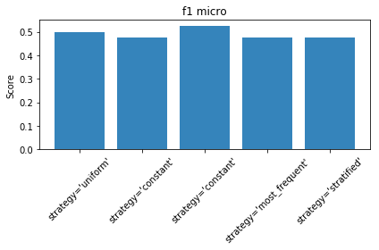

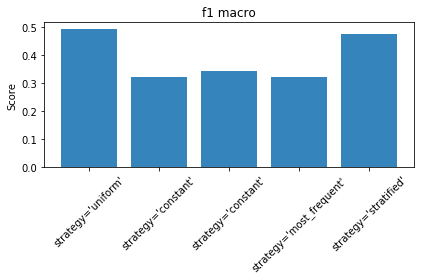

```python
gs_dm_clfs = [gs_uni, gs_con0, gs_con1, gs_mf, gs_st]

barplot_score(gs_dm_clfs, X_test, y_test)
```

Επείδη ο συμπεριφορά των dummies δεν επηρέαζεται κατά κύριο λόγο, απο την μεταβολή των υπερπαραμέτρων του πρώτου σταδίο, η ανάλυση που έχει πραγματοποιηθεί ήδη στο Μέρος Γ, μπορεί πολύ εύκολα να επαναληφθεί και εδώ. Όσο για τον χρόνο επειδή οι τιμές που μετρήσαμε είναι αρκετά μικρές, καθώς δεν 'κουράζονται' στην προβλέψη τους, δεν κρίναμε αναγκαίο να τους τυπώσουμε με μορφή πίνακα.

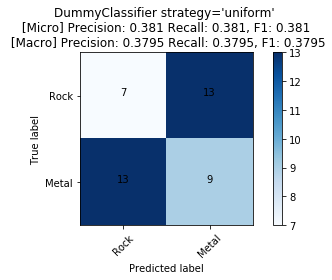

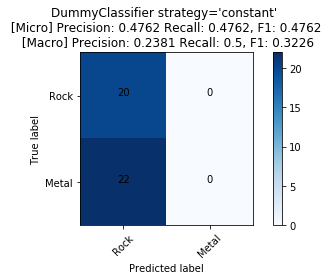

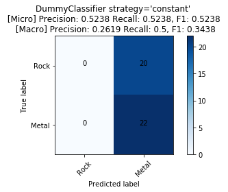

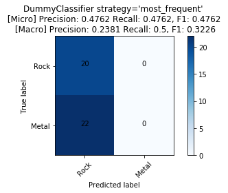

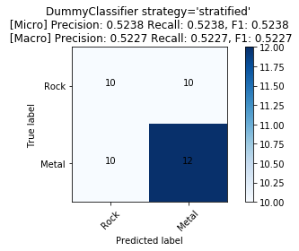

```python
plot_report(gs_dm_clfs, X_test, y_test, ["Rock", "Metal"])
```

### ΚΝΝ Μέρος Δ

Στο δεύτερο μισό του Μέρους Δ, όπως δηλώνει και ο τίτλος, θα αφιερωθούμε αποκλειστικά στον `KNN` καθώς είναι ο μόνος απο τους ταξινομητές που επιδέχεται παραμετροποιήση που αντανακλά στα αποτελέσματα. Θα χρησιμοποιήσουμε την κλάση `GridSearch` που φτιάξαμε για να προσεγγίσουμε καλές τιμές για τις υπερπαραμέτρους, και έπειτα θα προχωρήσουμε σε πιο ενδελεχή χειροκίνητο έλεγχο. Θα ξεκινήσουμε με μετρική `micro` και επειτα θα εξετάσουμε και την `macro`.

```python
grid = {
    "vthreshold" : np.arange(0, 0.06, 6),
    "n_components": [5, 10, 15, 20, 25, 30, 35, 40, 45],
    "k_neighbors" : [1, 3, 5, 7, 9, 11, 12, 15]
}

knn_s = KNeighborsClassifier()
gs_knn_s = GridSearch(knn_s, grid, cv=10, scoring="f1_micro", over_sampling=True, std_scale=True)

start_time = time.time()
gs_knn_s.fit(X_train, y_train)
preds_knn_s = gs_knn_s.predict(X_test)
print("Total time for fit and predict: %s seconds" % (time.time() - start_time))
```

```
Total time for fit and predict: 1.8382198810577393 seconds
```

```python
print(gs_knn_s.best_params_, gs_knn_s.best_estimator_)
```

```
{'VarianceThreshold': 0.0, 'PCA_components': 15.0, 'Standard_Scaler': True, 'Over_Sampling': True, 'KNN_neighbors': 3.0} KNeighborsClassifier(algorithm='auto', leaf_size=30, metric='minkowski',
           metric_params=None, n_jobs=None, n_neighbors=3, p=2,
           weights='uniform')
```

```python
print(classification_report(y_test, preds_knn_s))
```

```
              precision    recall  f1-score   support

           0       0.88      0.75      0.81        20
           1       0.80      0.91      0.85        22

   micro avg       0.83      0.83      0.83        42
   macro avg       0.84      0.83      0.83        42
weighted avg       0.84      0.83      0.83        42
```

Ως πρώτη αλλαγή θα αφαιρέσουμε το over sampling για να δούμε πως θα αντιδράσει το `GridSearch` ως προς την επιλογή των υπόλοιπων παραμέτρων.

```python
grid = {
    "vthreshold" : [0],
    "n_components": [5, 10, 15, 20, 25, 30, 35, 40, 45],
    "k_neighbors" : [1, 3, 5, 7, 9, 11, 12, 15]
}

knn_s1 = KNeighborsClassifier()
gs_knn_s1 = GridSearch(knn_s1, grid, cv=10, scoring="f1_micro", over_sampling=False, std_scale=True)

start_time = time.time()
gs_knn_s1.fit(X_train, y_train)
preds_knn_s1 = gs_knn_s1.predict(X_test)
print("Total time for fit and predict: %s seconds" % (time.time() - start_time))
```

```
Total time for fit and predict: 1.9602367877960205 seconds
```

```python
print(gs_knn_s1.best_params_, gs_knn_s1.best_estimator_)
```

```
{'VarianceThreshold': 0.0, 'PCA_components': 20.0, 'Standard_Scaler': True, 'Over_Sampling': False, 'KNN_neighbors': 3.0} KNeighborsClassifier(algorithm='auto', leaf_size=30, metric='minkowski',
           metric_params=None, n_jobs=None, n_neighbors=3, p=2,
           weights='uniform')
```

```python
print(classification_report(y_test, preds_knn_s1))
```

```
              precision    recall  f1-score   support

           0       0.84      0.80      0.82        20
           1       0.83      0.86      0.84        22

   micro avg       0.83      0.83      0.83        42
   macro avg       0.83      0.83      0.83        42
weighted avg       0.83      0.83      0.83        42
```

Και τα δύο αποτελέσματα αν και σχετικά ίσα, μας υποδηλώνουν δύο πράγματα.

- Οι γείτονες του `KNN` που οδηγούν στην μεγαλύτερη τιμή του $f1$ κυμαίνεται είναι μία εκ των τριών $[1,3,5]$, και κυρίως $[1,3]$.
- Οι τιμές μεταξύ $[10, 25]$ εμφανίζουν καλύτερα αποτελέσματα για τα PCA Components

Σύμφωνα με τις παραπάνω δύο παρατηρήσεις θα περιορίσουμε την περιοχή των τιμών γύρω απο αυτές που είχαν υψηλότερη απόδοση.

```python
grid = {
    "vthreshold" : [0],
    "n_components": [10, 15, 18, 19, 20, 21, 22],
    "k_neighbors" : [1, 3, 5]
}

knn_s3 = KNeighborsClassifier()
gs_knn_s3 = GridSearch(knn_s1, grid, cv=10, scoring="f1_micro", over_sampling=False, std_scale=True)

start_time = time.time()
gs_knn_s3.fit(X_train, y_train)
preds_knn_s3 = gs_knn_s3.predict(X_test)
print("Total time for fit and predict: %s seconds" % (time.time() - start_time))
```

```
Total time for fit and predict: 0.6383042335510254 seconds
```

```python
print(gs_knn_s3.best_params_, gs_knn_s3.best_estimator_)
```

```
{'VarianceThreshold': 0.0, 'PCA_components': 20.0, 'Standard_Scaler': True, 'Over_Sampling': False, 'KNN_neighbors': 3.0} KNeighborsClassifier(algorithm='auto', leaf_size=30, metric='minkowski',
           metric_params=None, n_jobs=None, n_neighbors=3, p=2,
           weights='uniform')
```

```python
print(classification_report(y_test, preds_knn_s3))
```

```
              precision    recall  f1-score   support

           0       0.84      0.80      0.82        20
           1       0.83      0.86      0.84        22

   micro avg       0.83      0.83      0.83        42
   macro avg       0.83      0.83      0.83        42
weighted avg       0.83      0.83      0.83        42
```

Οι υπεράμετροι που επιλέγει είναι οι ίδιοι με προηγούμενως. Σε αυτό το σημείο θα ασχοληθούμε με την χειροκίνητη παραμετροποίηση, λίγων τιμών.

- k=1, n=20
- k=1, n=21

```python
selector = VarianceThreshold()
scaler = StandardScaler()
pca = PCA(n_components=20)
clf = KNeighborsClassifier(n_neighbors=1, n_jobs=-1)

X_train_mod = scaler.fit_transform(X_train)
X_train_mod = pca.fit_transform(X_train_mod)

clf.fit(X_train_mod, y_train)

X_test_mod = scaler.transform(X_test)
X_test_mod = pca.transform(X_test_mod)

preds = clf.predict(X_test_mod)

print(precision_recall_fscore_support(y_test, preds, average="micro"))
print(classification_report(y_test, preds))
```

```
(0.8809523809523809, 0.8809523809523809, 0.8809523809523809, None)
              precision    recall  f1-score   support

           0       0.94      0.80      0.86        20
           1       0.84      0.95      0.89        22

   micro avg       0.88      0.88      0.88        42
   macro avg       0.89      0.88      0.88        42
weighted avg       0.89      0.88      0.88        42
```

```python
selector = VarianceThreshold()
scaler = StandardScaler()
pca = PCA(n_components=21)
clf = KNeighborsClassifier(n_neighbors=1, n_jobs=-1)

X_train_mod = scaler.fit_transform(X_train)
X_train_mod = pca.fit_transform(X_train_mod)

clf.fit(X_train_mod, y_train)

X_test_mod = scaler.transform(X_test)
X_test_mod = pca.transform(X_test_mod)

preds = clf.predict(X_test_mod)

print(precision_recall_fscore_support(y_test, preds, average="micro"))
print(classification_report(y_test, preds))
```

```
(0.8809523809523809, 0.8809523809523809, 0.8809523809523809, None)
              precision    recall  f1-score   support

           0       0.94      0.80      0.86        20
           1       0.84      0.95      0.89        22

   micro avg       0.88      0.88      0.88        42
   macro avg       0.89      0.88      0.88        42
weighted avg       0.89      0.88      0.88        42
```

Τα αποτέλεσμα δεν διαφέρουν καθόλου για αυτό θα παραμείνουμε στην τιμή 20 για την παράμετρο `PCA Components`, και θα δοκιμάσουμε μεταξύ δύο τιμών για τον `KNN`.

- k=1
- k=3

```python
selector = VarianceThreshold()
scaler = StandardScaler()
pca = PCA(n_components=20)
clf = KNeighborsClassifier(n_neighbors=3, n_jobs=-1)

X_train_mod = scaler.fit_transform(X_train)
X_train_mod = pca.fit_transform(X_train_mod)

clf.fit(X_train_mod, y_train)

X_test_mod = scaler.transform(X_test)
X_test_mod = pca.transform(X_test_mod)

preds = clf.predict(X_test_mod)

print(precision_recall_fscore_support(y_test, preds, average="micro"))
print(classification_report(y_test, preds))
```

```
(0.8333333333333334, 0.8333333333333334, 0.8333333333333334, None)
              precision    recall  f1-score   support

           0       0.84      0.80      0.82        20
           1       0.83      0.86      0.84        22

   micro avg       0.83      0.83      0.83        42
   macro avg       0.83      0.83      0.83        42
weighted avg       0.83      0.83      0.83        42
```

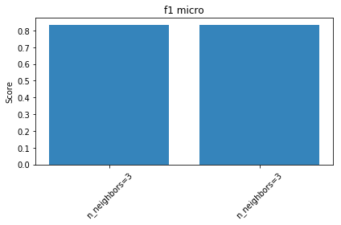

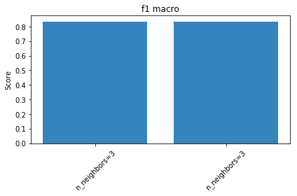

```python
gs_knns = [gs_knn_s, gs_knn_s1]

barplot_score(gs_knns, X_test, y_test)
```

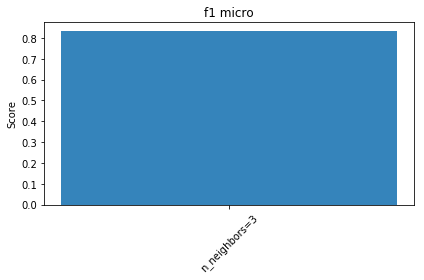

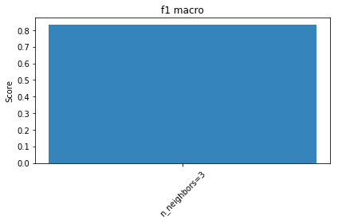

```python
barplot_score(clf, X_test_mod, y_test)
```

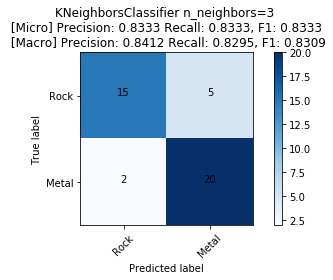

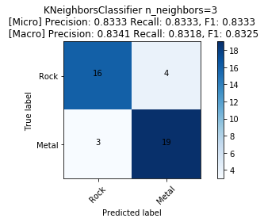

```python
plot_report(gs_knns, X_test, y_test, ["Rock", "Metal"])
```

```
[0.31551881 0.52903108 0.60628562 0.67137453 0.72460512 0.76887271
 0.81001813 0.83616935 0.85808019 0.87708497 0.89272373 0.90738218
 0.91903633 0.9296181  0.93862143 0.94700095 0.95461641 0.96039019
 0.96555877 0.97031293 0.97420525 0.97719455 0.9797794  0.98231849
 0.98466133 0.98653561 0.9881182  0.98937433 0.99060542 0.9917899
 0.99269518 0.99351053 0.99428202 0.99503601 0.99570424 0.99630339
 0.99683036 0.99733077 0.99776414 0.99814984 0.99849707 0.99880283
 0.99906602 0.99929025 0.99946558 0.99960661 0.99969749 0.99977202
 0.99983973 0.99987818]
```

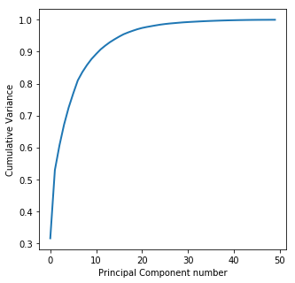

```python
pca = PCA(n_components=50)
pca.fit_transform(X_train)

evar = pca.explained_variance_ratio_
cum_evar = np.cumsum(evar)
print(cum_evar)
plt.figure(1, figsize=(5, 5))
plt.xlabel("Principal Component number")
plt.ylabel('Cumulative Variance')
plt.plot(cum_evar, linewidth=2)
plt.show()
```

Παρατηρούμε ότι για τιμές 20+ οι κύριες συνιστώσες καταφέρνουν να περιγράψουν σχεδον το $95%$ των δεδομένων μας. Για αυτό το λόγω όταν οι διαστάσει ξεφέυγουν πάνω απο 25+, τα δεδομένα μας δεν αρκούν για να εκπαιδεύσουν πλήρως τον ταξινομητή μας. (Curse of dimensionality)